# RNA-seq Analysis in R

Annotation and Visualisation of RNA-seq results

Mark Dunning

Last modified: 08 Jul 2018

**Original Authors: Belinda Phipson, Anna Trigos, Matt Ritchie, Maria Doyle, Harriet Dashnow, Charity Law**, **Stephane Ballereau, Oscar Rueda, Ashley Sawle** Based on the course [RNAseq analysis in R](http://combine-australia.github.io/2016-05-11-RNAseq/) delivered on May 11/12th 2016

Before starting this section, we will make sure we have all the relevant objects from the Differential Expression analysis present.

```r
suppressPackageStartupMessages(library(DESeq2))
load("Robjects/DE.Rdata")
load("Robjects/preprocessing.Rdata")
```

# Overview

- Visualising DE results
- Getting annotation
- Retrieving gene models
- Exporting browser traecks
- Visualising results with respect to genomic location

We can now have a list of genes ordered according to their evidence for being differentially-expressed.

```r
results.status <- results(de.status)
results.ordered <- results.status[order(results.status$padj,decreasing = FALSE),]
results.ordered
```

```
log2 fold change (MLE): Status virgin vs lactate
Wald test p-value: Status virgin vs lactate
DataFrame with 15804 rows and 6 columns
                  baseMean      log2FoldChange             lfcSE                stat               pvalue
                 <numeric>           <numeric>         <numeric>           <numeric>            <numeric>
67111     306.660254651116   -2.23324872926005  0.15788538108878   -14.1447467388021 2.01239829443001e-45
170459    398.929351766412   -2.52810779567362 0.218040292013263   -11.5946817550576 4.38492517229431e-31
100042069 2933.24847370486     1.2350233918969 0.111560608993607    11.0704253323651 1.74570071259733e-28
77697     207.871696302787   -1.63202801130171 0.152928644173235   -10.6718268518289 1.37888326090268e-26
12704     55.9983320945389    3.18546655562673 0.298956821338253    10.6552730302901 1.64760487478274e-26
...                    ...                 ...               ...                 ...                  ...
436090    15.7392473236157 0.00269874155277329  1.09678950809848 0.00246058294034206    0.998036740842408
210297    102.038473754967 0.00411586173534536  1.79885051177219 0.00228805101280511    0.998174401015443
215866    86.3233023728964   -2.20498222544774  1.84588815645805   -1.19453728425168                   NA
76507     12.8006916703199    4.69037284702865  1.32984942976575    3.52699541921437                   NA
19259     16.2110026199967    4.43777309329389  2.59380579175385    1.71091186063441                   NA
                          padj
                     <numeric>
67111     3.17979054502886e-41
170459    3.46431013237112e-27
100042069 9.19460565325012e-25
77697      5.2067609252884e-23
12704      5.2067609252884e-23
...                        ...
436090       0.999988927590533
210297       0.999988927590533
215866                      NA
76507                       NA
19259                       NA
```

In `DESeq2`, the function plotMA shows the log2 fold changes attributable to a given variable over the mean of normalized counts for all the samples in the DESeqDataSet. Points will be colored red if the adjusted p value is less than 0.1. Points which fall out of the window are plotted as open triangles pointing either up or down.

The log2 fold change for a particular comparison is plotted on the y-axis and the average of the counts normalized by size factor is shown on the x-axis (“M” for minus, because a log ratio is equal to log minus log, and “A” for average). Each gene is represented with a dot. Genes with an adjusted p value below a threshold (here 0.1, the default) are shown in red.

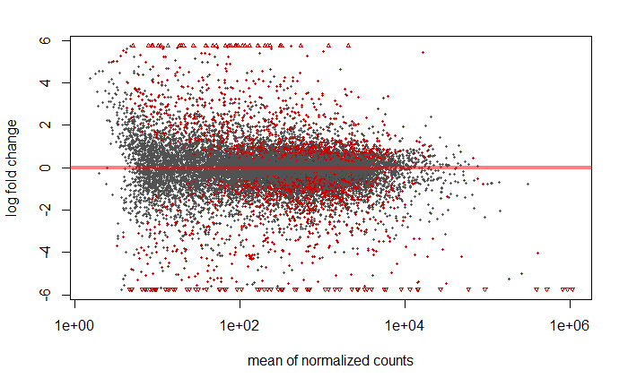

```r
plotMA(de.status)
```

*Note* You may see an error message when trying to make the above MA plot. This could be because both `limma` and `DESeq2` have a function called `plotMA`, and R can sometimes pick the wrong function. To explictly use the `DESeq2` function you can use:-

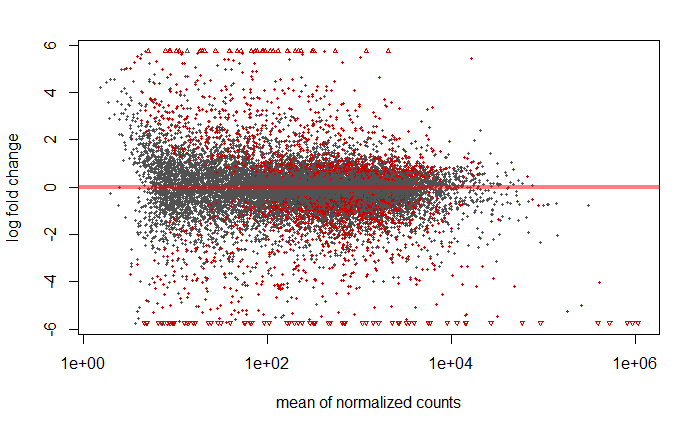

```r
DESeq2::plotMA(de.status)
```

Another common plot for displaying the results of a differential expression analysis is a *volcano plot*

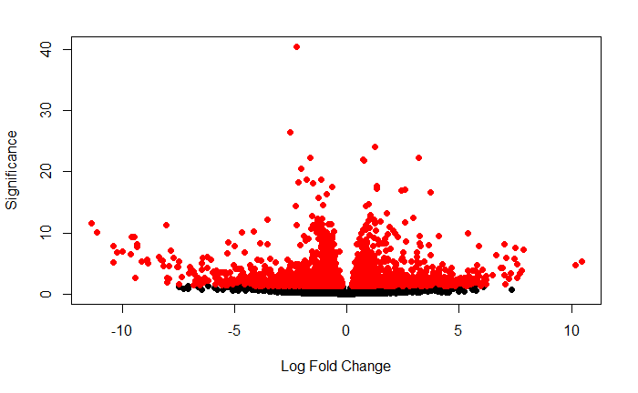

```r
plot(results.ordered$log2FoldChange, -log10(results.ordered$padj),
     pch=16,
     xlab="Log Fold Change",
       ylab="Significance")
degenes <- which(results.ordered$padj < 0.05)
points(results.ordered$log2FoldChange[degenes],-log10(results.ordered$padj)[degenes],
       col="red",
       pch=16)
```

It can also be useful to examine the counts of reads for a single gene across the groups. A simple function for making this plot is `plotCounts`, which normalizes counts by sequencing depth and adds a pseudocount of 1/2 to allow for log scale plotting. The counts are grouped by the variables in `intgroup`, where more than one variable can be specified. Here we specify the gene which had the smallest p value from the results table created above. You can select the gene to plot by rowname or by numeric index:-

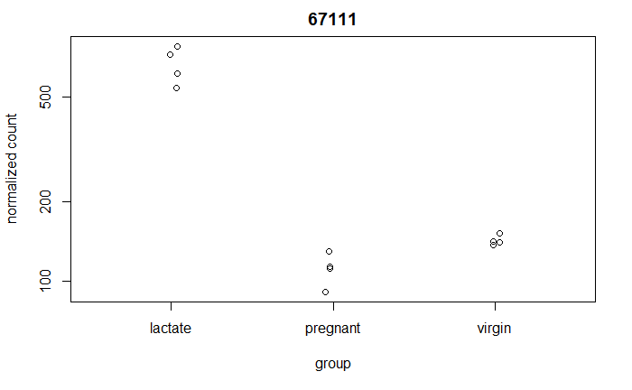

```r
plotCounts(dds, "67111",intgroup = c("Status"))
```

## Challenge 1

> 1. What is the Entrez ID of the gene with the lowest p-value in the lactate vs virgin contrast?
> 2. Plot the counts to compare the expression of this gene in virgin vs lactate